# Panel merging

Christina Bligaard Pedersen

February 25, 2021

This vignette will introduce the panel merging module of cyCombine which has two main functions:

1. Imputation of non-overlapping channels for whole data sets (`impute_across_panels`)
2. Imputation of single misstained (or in some other way) problematic channels (`salvage_problematic`)

These modules rely on the same main workflow, as represented by this figure:

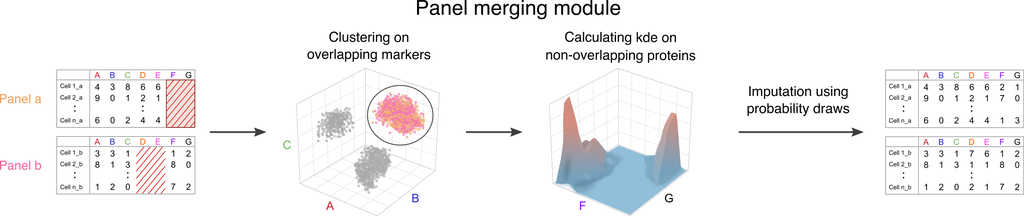

In this vignette, we will look at these functions separately and also provide some discussion performance metrics.

## Imputation of non-overlapping channels for whole data sets

Mass cytometry and spectral flow cytometry enables quantification of ~40 proteins in parallel on millions of cells. But sometimes that is not enough to deeply characterize the populations of interest. The solution: Use two or more panels on the same cells - i.e. split you samples before staining. When this is done, however, one essentially ends up with two different datasets. Usually, these overlap partially - after all, most cytometry panels contain some of the most important cell type markers; CD3, CD4, CD8, CD14, CD19, CD56 etc. But it still is challenging to jointly analyze the data. The panel merging module of cyCombine can help researchers facing this exact challenge. Based on the overlapping markers, cyCombine is able to impute the values for the non-overlapping set, enabling co-analysis with all the markers across the applied panels.

Another example, which may be important for larger dataset integration - either across studies or platforms - is data analyzed with two different, partially overlapping panels.

### Methodology

cyCombine’s cross-dataset merging works by first performing a SOM-based (default 8x8) clustering of the datasets based on all of the overlapping markers. Then, for each cell in one of the datasets, the values for the missing markers are imputed by using the values from cells in the other dataset that fall within the same SOM node. The imputations are made by simulating a multi-dimensional kernel density estimate: Each cell’s missing values are imputed by randomly drawing a cell from the other dataset and adding a Gaussian error, which is based on a draw from a Normal distribution with mean 0 and standard deviation corresponding to the bandwidth of each marker.

However, if there are less than 50 cells from the other dataset within the SOM node, the values for the missing channels are set to NA as imputation would be unreliable.

We refer to the cyCombine vignette with a [two-panel CyTOF dataset](https://htmlpreview.github.io/?https://github.com/shdam/cyCombine/blob/master/vignettes/CyTOF_2panels.html) for a panel merging use-case.

In this vignette, we will instead focus a bit on the landscape of integration and imputation, before proceeding to an introduction to imputation of single misstained channels.

### Discussion

In terms of advantages, the approach of cyCombine is designed to account for the underlying biology by using density draws. This is particularly important because cytometry data are not normally distributed.

In some cases, in which the variance in the marker expression is very low, and measures like the median provide a good estimate of the values to be imputed. The unfortunate thing is that those cases are often biologically uninteresting, whereas markers with bimodal expression are often the center of attention. Such markers can either be relevant for distinguishing populations and downstream differential abundance analysis, or within a cluster they may provide insight into differential expression between experimental states.

When evaluating cyCombine, it is important to consider the following: Because of the use of density draws, it is not possible to use a one-one comparison of cells in a training set before and after imputation. This is because you might actually get some ‘wrong’ estimates with our approach - but there should be a corresponding ‘wrong’ estimate making up for that. The goal of our SOM/density-based approach is to preserve the global structure of the dataset instead of the single cell’s assignment. An additional upside to cyCombine is that it also does not exclude outlier values, as those should be sampled with the frequency that they are actually present in the data.

Naturally, this approach also has limitations: Since the method relies on the information of the overlapping markers for imputation, this overlap must be of a reasonable size and quality. This is hard to accurately define, but overall, the overlapping set should contain the most important lineage-defining markers, for imputation to work properly. Also, we would err on the side of caution when it comes to the number of markers imputed: Do not impute 100 markers based on five overlapping. How far to push this will depend on the overlap in question and also the samples. If the samples are highly similar, as in a two-panel analysis of the same samples, perhaps it is okay to impute, but if they are very different, such as from different diseases or tissues, one should be more careful.

Furthermore, we will advise against using imputed values for differential expression analysis, as this can be highly sensitive to the values. Instead, panel merging should be viewed as a tool for easing data visualization - you can get *one* UMAP for multi-panel data and the population abundances will be directly comparable sparring researchers from the trouble of having to do cluster matching (difficult) and studying separate plots since data exists in two spaces.

#### Other integration anf imputation tools

Previous work by [Abdelaal et al. (2019)](https://doi.org/10.1093/bioinformatics/btz180) suggested the CyTOFmerge approaches for 1) designing panels with an optimal overlap for imputation and 2) imputation based on k-Nearest Neighbors (kNN) and medians. However, the authors state that it is best to use their own panel design tool if panel merging is to work optimally.

While the idea of designing multiple panels so they have an ideal information-carrying overlap is very good and should be considered best-practice, it is also not carried out in many real-life studies, in which the bioinformatician analyzing the data may only have been included after the data was generated on the CyTOF instrument. This often results in a situation where two panels with sub-optimal overlap have been run, but this is the available data.

As a result, comparing cyCombine and CyTOFmerge directly would not be fair, as they are not designed with the same purpose in mind.

We must also mention CytoBackBone by [Pereira et al. (2019)](https://doi.org/10.1093/bioinformatics/btz212), which also uses nearest-neighbor imputation. An interesting notion of acceptable neighbors is applied to avoid spurious imputations based on very distinct cells. This is analogous to cyCombine’s lack of imputation in cases where a SOM node contains no/very few cells from one of the datasets. Furthermore, they provide a very interesting test case, in which a healthy donor sample was stained with five combinations of the same set of 35 markers, which we will focus on in the next section. This work also tested the impact of the size of the set of overlapping markers using more than 65,000 different combinations, showing that the larger the overlap, the better the imputation quality.

Alternatively, one could look to the flow cytometry work by [Lee et al. (2011)](https://doi.org/10.1016/j.jbi.2011.03.004), which suggests a clustering-based approach for imputation. This model was however developed for two data files only and relies on the application of domain knowledge regarding marker expression of different cell types. Furthermore, it was only tested on lymphocyte data.

For combining and integrating datasets, approaches like QFMatch by [Orlova et al. (2018)](https://doi.org/10.1038/s41598-018-21444-4), SIC by [Meehan et al. (2019)](https://doi.org/10.1038/s42003-019-0467-6), and MetaCyto by [Hu et al. (2018)](https://doi.org/10.1016/j.celrep.2018.07.003) have been presented. However, these are focused on combining the results of complete analyses with cluster matching and not on allowing truly integrated analysis from start to end.

#### Mini-benchmark

Along with the CytoBackBone publication, a whole blood dataset from a healthy donor was published (FlowRepository ID: FR-FCM-ZYV2). This donor was stained with five different panels, four of which were subsets of the full panel (#E). We downloaded the five pregated files from the repository and now we will read them and perform panel merging.

Panel #A and #B together have all the 35 markers included in panel #E, with an overlap of 16 markers. Similarly, panel #C and #D together have all the 35 markers included in panel #E, with an overlap of the same 16 markers. These 16 markers are, as would be a recommended choice, some of the key lineage markers: CD1c, CD3, CD4, CD8a, CD11c, CD14, CD16, CD19, CD32, CD64, CD66, CD86, CD123, CD141, Granzyme B, and HLA-DR. In the original article, they conduct an analysis regarding the importance of each backbone marker, in which markers are ranked based on their relative importance (CD3 and CD66 being the most important). We will not conduct a similar analysis, but instead focus on comparing cyCombine and CytoBackBone.

```r
library(cyCombine)
library(tidyverse)
```

```r
# Set data directory
data_dir <- "FR-FCM-ZYV2/"

# Load five panels' data - here we assume no substantial
# batch effects between the five samples
panel_A <- prepare_data(data_dir = data_dir, pattern = "#A",
    down_sample = F, batch_ids = "A", sample_ids = 1)
panel_B <- prepare_data(data_dir = data_dir, pattern = "#B",
    down_sample = F, batch_ids = "B", sample_ids = 1)
panel_C <- prepare_data(data_dir = data_dir, pattern = "#C",
    down_sample = F, batch_ids = "C", sample_ids = 1)
panel_D <- prepare_data(data_dir = data_dir, pattern = "#D",
    down_sample = F, batch_ids = "D", sample_ids = 1)
panel_E <- prepare_data(data_dir = data_dir, pattern = "#E",
    down_sample = F, batch_ids = "E", sample_ids = 1)
```

We will do panel merging with two panels at a time. Let us first focus on panels A and B.

```r
# Define the overlap (16 markers)
overlap_AB <- intersect(get_markers(panel_A), get_markers(panel_B))

# Define markers unique to each panel
missing_A <- get_markers(panel_B)[!(get_markers(panel_B) %in%
    overlap_AB)]
missing_B <- get_markers(panel_A)[!(get_markers(panel_A) %in%
    overlap_AB)]

# Perform imputations (and measure runtime)
start_time_cC <- Sys.time()
panel_AB <- impute_across_panels(dataset1 = panel_A, dataset2 = panel_B,
    overlap_channels = overlap_AB, impute_channels1 = missing_A,
    impute_channels2 = missing_B)
end_time_cC <- Sys.time()

# Combine the dataframes for each set
panel_AB <- rbind(panel_AB$dataset1, panel_AB$dataset2)
```

And then let us integrate panels C and D.

```r
# Define the overlap (16 markers)
overlap_CD <- intersect(get_markers(panel_C), get_markers(panel_D))

# Define markers unique to each panel
missing_C <- get_markers(panel_D)[!(get_markers(panel_D) %in%
    overlap_CD)]
missing_D <- get_markers(panel_C)[!(get_markers(panel_C) %in%
    overlap_CD)]

# Perform imputations
panel_CD <- impute_across_panels(dataset1 = panel_C, dataset2 = panel_D,
    overlap_channels = overlap_CD, impute_channels1 = missing_C,
    impute_channels2 = missing_D)


# Combine the dataframes for each set
panel_CD <- rbind(panel_CD$dataset1, panel_CD$dataset2)
```

Now that both sets of panel pairs have been integated, we can compare the Earth Mover’s Distance to panel E which contained the full set of markers. First, we will look at the densities of each marker - both for the overlapping channels and the imputed ones.

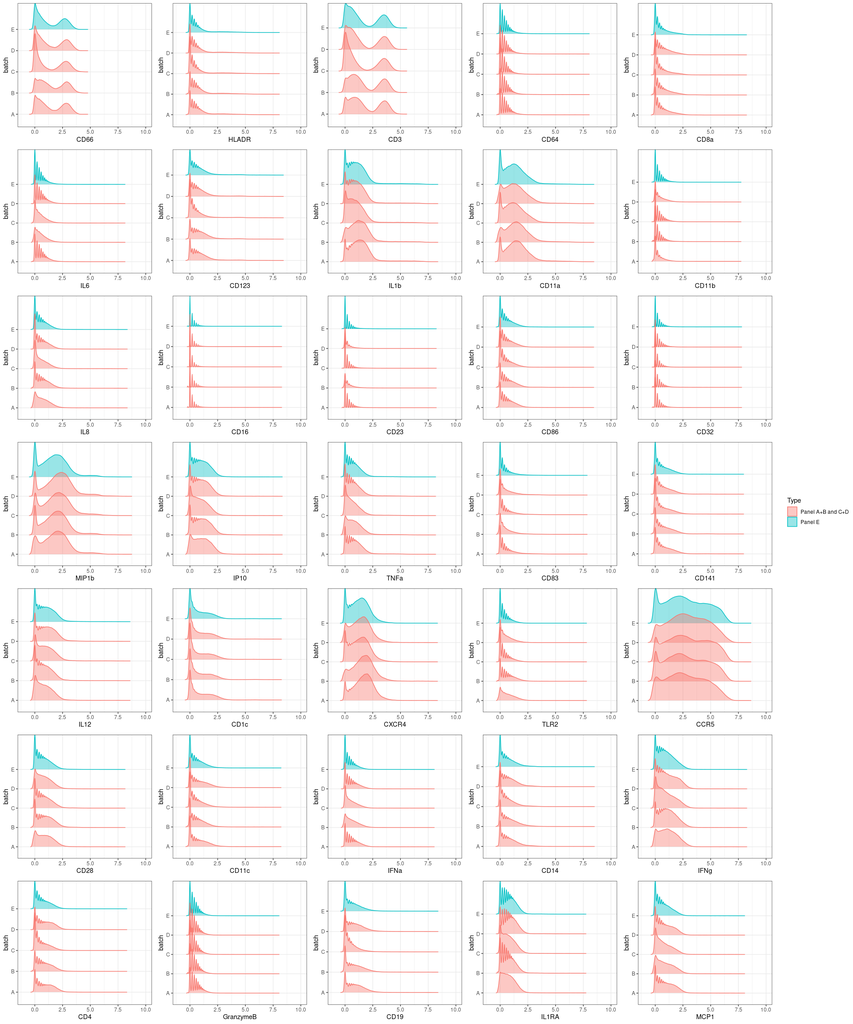

```r
# And let's look at the marker density of A+B and C+D
# relative to the full panel (E)
plot_density(uncorrected = panel_E, corrected = rbind(panel_AB[,
    colnames(panel_E)], panel_CD[, colnames(panel_E)]), dataset_names = c("Panel E",
    "Panel A+B and C+D"), ncol = 5)
```

Overall, this looks quite good. Even looking at a marker like CD3, which was a part of all five panels, the distributions are not completely identical, so it would be a hard requirement to impose on imputations. Now, we will use the Earth Mover’s Distance (EMD) to look at the imputations more quantitatively.

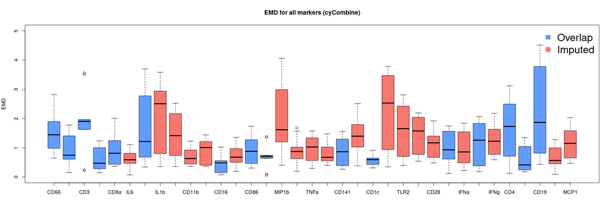

```r
# Combine all datasets
combined <- rbind(panel_AB[, colnames(panel_E)], panel_CD[, colnames(panel_E)],
    panel_E)

# EMD calculations for all batches - here we perform these
# globally, since the datasets are from the same healthy
# donor sample
emd_all <- compute_emd(df = combined, cell_col = "sample")[[1]]

boxplot(emd_all, main = "EMD for all markers (cyCombine)", ylab = "EMD",
    col = c("#F8766D", "#619CFF")[as.numeric(names(emd_all) %in%
        overlap_AB) + 1], ylim = c(0, 5))
legend("topright", legend = c("Overlap", "Imputed"), col = c("#619CFF",
    "#F8766D"), pch = 15, cex = 2, bty = "n")
```

Now, we compare these results to those of CytoBackBone. In this process, we aim to apply the exact approach presented in the CytoBackBone GitHub and consequently, we load the files again to make sure we are not adding any bias to the analysis.

```r
# Load package
library(CytoBackBone)  # v. 1.0.0
# Import of FCS files (includes asinh-tranformation)
panel_A_CBB <- import.FCS(paste0(data_dir, "/HEA_profile#A_pregated.fcs"))
```

```
Importing FR-FCM-ZYV2//HEA_profile#A_pregated.fcs
```

```r
panel_B_CBB <- import.FCS(paste0(data_dir, "/HEA_profile#B_pregated.fcs"))
```

```
Importing FR-FCM-ZYV2//HEA_profile#B_pregated.fcs
```

```r
panel_C_CBB <- import.FCS(paste0(data_dir, "/HEA_profile#C_pregated.fcs"))
```

```
Importing FR-FCM-ZYV2//HEA_profile#C_pregated.fcs
```

```r
panel_D_CBB <- import.FCS(paste0(data_dir, "/HEA_profile#D_pregated.fcs"))
```

```
Importing FR-FCM-ZYV2//HEA_profile#D_pregated.fcs
```

```r
panel_E_CBB <- import.FCS(paste0(data_dir, "/HEA_profile#E_pregated.fcs"))
```

```
Importing FR-FCM-ZYV2//HEA_profile#E_pregated.fcs
```

Now that the files are loaded, we are ready to perform the integration with CytoBackBone. Here, we choose to use the normalization of the tool and a threshold of 3, which is a relatively high threshold meaning that more cells will be included in the integrated set.

```r
# Merging of cytometry profiles using CytoBackBone Panels A +
# B (measuring runtime)
start_time_CBB <- Sys.time()
panel_AB_CBB <- CytoBackBone::merge(FCS1 = panel_A_CBB, FCS2 = panel_B_CBB,
    BBmarkers = overlap_AB, th = 3, leftout = T, normalize = T)
```

```
=== CytoBackBone ===
Normalizing profiles
processing marker: CD66
processing marker: HLADR
processing marker: CD3
processing marker: CD64
processing marker: CD8a
processing marker: CD123
processing marker: CD16
processing marker: CD86
processing marker: CD32
processing marker: CD141
processing marker: CD1c
processing marker: CD11c
processing marker: CD14
processing marker: CD4
processing marker: GranzymeB
processing marker: CD19
profile 1 contains 162,741 cells
profile 2 contains 159,468 cells
===
profile 1 has 162,491 cells can be potentialy matched
profile 2 has 159,235 cells can be potentialy matched
===
maximum of number of cells that can be matched by CytoBackBone = 159,235
===
step #1: 51,951 cells matched (107,284 cells remaining)
step #2: 74,112 cells matched (85,123 cells remaining)
step #3: 87,849 cells matched (71,386 cells remaining)
step #4: 97,961 cells matched (61,274 cells remaining)
step #5: 106,038 cells matched (53,197 cells remaining)
step #6: 112,641 cells matched (46,594 cells remaining)
step #7: 118,161 cells matched (41,074 cells remaining)
step #8: 122,867 cells matched (36,368 cells remaining)
step #9: 126,851 cells matched (32,384 cells remaining)
step #10: 130,064 cells matched (29,171 cells remaining)
step #11: 132,760 cells matched (26,475 cells remaining)
step #12: 135,036 cells matched (24,199 cells remaining)
step #13: 136,919 cells matched (22,316 cells remaining)
step #14: 138,483 cells matched (20,752 cells remaining)
```

[output cut: 18 more lines]

```
step #33: 153,687 cells matched (5,548 cells remaining)
step #34: 153,943 cells matched (5,292 cells remaining)
step #35: 154,177 cells matched (5,058 cells remaining)
step #36: 154,441 cells matched (4,794 cells remaining)
step #37: 154,724 cells matched (4,511 cells remaining)
step #38: 154,968 cells matched (4,267 cells remaining)
step #39: 155,158 cells matched (4,077 cells remaining)
step #40: 155,270 cells matched (3,965 cells remaining)
step #41: 155,348 cells matched (3,887 cells remaining)
step #42: 155,398 cells matched (3,837 cells remaining)
step #43: 155,430 cells matched (3,805 cells remaining)
step #44: 155,450 cells matched (3,785 cells remaining)
step #45: 155,458 cells matched (3,777 cells remaining)
step #46: 155,459 cells matched (3,776 cells remaining)
====================
```

```r
end_time_CBB <- Sys.time()

# Panels C + D
panel_CD_CBB <- CytoBackBone::merge(FCS1 = panel_C_CBB, FCS2 = panel_D_CBB,
    BBmarkers = overlap_CD, th = 3, leftout = T, normalize = T)
```

```
=== CytoBackBone ===
Normalizing profiles
processing marker: CD66
processing marker: HLADR
processing marker: CD3
processing marker: CD64
processing marker: CD8a
processing marker: CD123
processing marker: CD16
processing marker: CD86
processing marker: CD32
processing marker: CD141
processing marker: CD1c
processing marker: CD11c
processing marker: CD14
processing marker: CD4
processing marker: GranzymeB
processing marker: CD19
profile 1 contains 141,627 cells
profile 2 contains 163,035 cells
===
profile 1 has 141,497 cells can be potentialy matched
profile 2 has 162,642 cells can be potentialy matched
===
maximum of number of cells that can be matched by CytoBackBone = 141,497
===
step #1: 47,446 cells matched (94,051 cells remaining)
step #2: 67,670 cells matched (73,827 cells remaining)
step #3: 80,015 cells matched (61,482 cells remaining)
step #4: 88,856 cells matched (52,641 cells remaining)
step #5: 95,807 cells matched (45,690 cells remaining)
step #6: 101,610 cells matched (39,887 cells remaining)
step #7: 106,666 cells matched (34,831 cells remaining)
step #8: 110,999 cells matched (30,498 cells remaining)
step #9: 114,652 cells matched (26,845 cells remaining)
step #10: 117,788 cells matched (23,709 cells remaining)
step #11: 120,422 cells matched (21,075 cells remaining)
step #12: 122,623 cells matched (18,874 cells remaining)
step #13: 124,502 cells matched (16,995 cells remaining)
step #14: 126,101 cells matched (15,396 cells remaining)
```

[output cut: 23 more lines]

```
step #38: 140,478 cells matched (1,019 cells remaining)
step #39: 140,540 cells matched (957 cells remaining)
step #40: 140,585 cells matched (912 cells remaining)
step #41: 140,630 cells matched (867 cells remaining)
step #42: 140,685 cells matched (812 cells remaining)
step #43: 140,746 cells matched (751 cells remaining)
step #44: 140,798 cells matched (699 cells remaining)
step #45: 140,853 cells matched (644 cells remaining)
step #46: 140,920 cells matched (577 cells remaining)
step #47: 140,968 cells matched (529 cells remaining)
step #48: 141,000 cells matched (497 cells remaining)
step #49: 141,017 cells matched (480 cells remaining)
step #50: 141,024 cells matched (473 cells remaining)
step #51: 141,026 cells matched (471 cells remaining)
====================
```

In the case of panels A + B, we observe that 155,459 cells are part of the integrated set. For C + D, that number is 141,026. Using cyCombine, *all* cells were actually integrated resulting in 322,209 and 304,662 cells in the merged sets, respectively. This can be an important factor in downstream analysis, especially considering the potential loss of statistical power by having few cells in your dataset.

We will now look at the density plots for CytoBackBone.

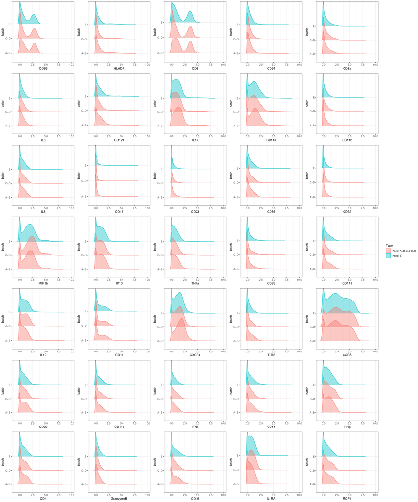

```r
# And let's look at the marker density of A+B and C+D
# relative to the full panel (E) First, we extract the marker
# expression values
panel_E_CBB_exp <- as.data.frame(panel_E_CBB@intensities)
colnames(panel_E_CBB_exp) <- panel_E_CBB@markers
panel_E_CBB_exp$batch = "E"
panel_AB_CBB_exp <- as.data.frame(panel_AB_CBB$merged@intensities)
colnames(panel_AB_CBB_exp) <- panel_AB_CBB$merged@markers
panel_AB_CBB_exp$batch = "A+B"
panel_CD_CBB_exp <- as.data.frame(panel_CD_CBB$merged@intensities)
colnames(panel_CD_CBB_exp) <- panel_CD_CBB$merged@markers
panel_CD_CBB_exp$batch = "C+D"

plot_density(uncorrected = panel_E_CBB_exp, corrected = rbind(panel_AB_CBB_exp[,
    colnames(panel_E_CBB_exp)], panel_CD_CBB_exp[, colnames(panel_E_CBB_exp)]),
    dataset_names = c("Panel E", "Panel A+B and C+D"), ncol = 5)
```

Again, we will use the Earth Mover’s Distance (EMD) to look at the imputations more quantitatively.

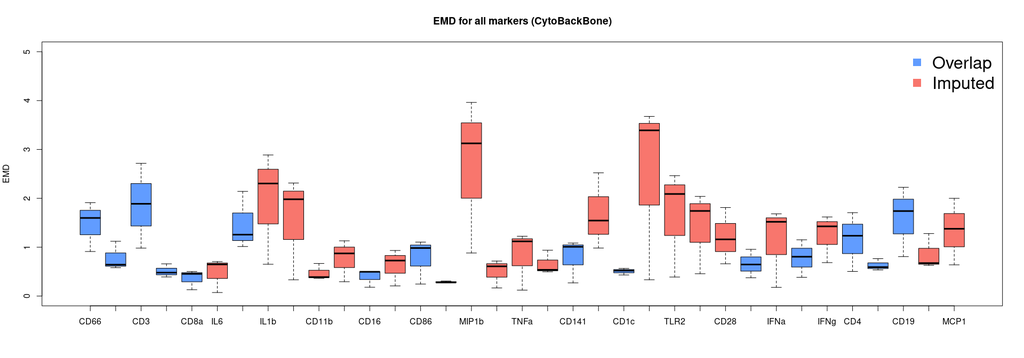

```r
# Combine all datasets
combined_CBB <- rbind(panel_AB_CBB_exp[, colnames(panel_E_CBB_exp)],
    panel_CD_CBB_exp[, colnames(panel_E_CBB_exp)], panel_E_CBB_exp)
combined_CBB$sample <- "1"

# EMD calculations for all batches - here we perform these
# globally, since the datasets are from the same healthy
# donor sample
emd_all_CBB <- compute_emd(df = combined_CBB, cell_col = "sample")[[1]]

boxplot(emd_all_CBB, main = "EMD for all markers (CytoBackBone)",
    ylab = "EMD", col = c("#F8766D", "#619CFF")[as.numeric(names(emd_all_CBB) %in%
        overlap_AB) + 1], ylim = c(0, 5))
legend("topright", legend = c("Overlap", "Imputed"), col = c("#619CFF",
    "#F8766D"), pch = 15, cex = 2, bty = "n")
```

Since the CytoBackBone function does not maintain the information about which panel, which cell originally came from after merging, there is no way to obtain all five EMD values. However, we will still compare the EMD boxplots directly. The EMD ranges are similar - i.e. both tools seem to be most challenged with markers such as CXCR4 and MIP1b.

A final comparison is the runtime. Here we do a small comparison of cyCombine and CytoBackBone on a machine with 40 cores and 100 gb memory:

```r
# Runtime for cyCombine on panels A + B
end_time_cC - start_time_cC
```

```
Time difference of 22.61814 secs
```

```r
# Runtime for CytoBackBone on panels A + B
end_time_CBB - start_time_CBB
```

```
Time difference of 14.14607 mins
```

While neither of these runtimes are terrible, it is worth considering that cyCombine is a lot faster.

In conclusion, the two tools have very similar performance in terms of the global distributions as seen from both the EMD calculations and the density plots. However, cyCombine integrates more cells and has a shorter runtime.

## Imputation of single misstained channels

Imagine that you have run an expensive and time-consuming cytometry experiment. You have 100+ samples and despite the ability to use barcoding for sample multiplexing you have run several batches. However, now that you visualize the data, you notice that the expression level for a marker in one of the batches looks very different than in the others. It may be strongly over-stained - or maybe there is no signal at all - maybe the antibody was damaged during the sample preparation.

In any case, you really wish that you could correct this marker in this single batch. This is because you need the marker for clustering - and if it’s non-sensical in one batch it could ruin the whole analysis plan. Enter cyCombine! In particular the `salvage_problematic` function, which allows imputation of a single marker in user-specified batches. The function uses the information found in all other markers in the combined dataset to determine the most likely value for the single marker. This vignette will demonstrate how.

But first, we will discuss when using this function is a good idea as opposed to just relying on batch correction.

### When to apply imputation

In some experiments with misstained channels, the analyst may be faced with the dilemma of whether to use batch correction or imputation. The answer will depend on the individual case, but in general, if we consider a problem similar to the one presented for XCL1 in panel 1 of the DFCI data (below), it becomes a question of whether one believes that the channel is simply over-stained, but with a direct correlation between measurements and actual expression, or if there is no relation between the two. In the first case, batch correction is the answer, as it represents the most data-preserving approach. However, if the data cannot be trusted it is better to rely on imputation.

Another case could be that a marker was completely left out - maybe there was no more left - or maybe it was forgotten during staining. In that case, the answer is imputation since there is no signal in the raw dataset to rely on for batch correction. But if the problem is due to using a different antibody lot with a markedly different signal or perhaps a different concentration, it is likely that batch correction would suffice. The same holds for cases with higher background in some batches.

### Methodology

The misstained channel correction relies on the same principles as the across-panel imputation, but instead of transferring information in one dataset to another, it utilizes the different batches of a single dataset.

First, a SOM (default 8x8) is calculated based on overlapping proteins. Then it applies the simulated multidimensional kernel density estimates (kde) on non-overlapping proteins, and performs imputations using probability draws from the kde.

### Imputation example

This is data from a study of CLL patients and healthy donors at the Dana-Farber Cancer Institute (DFCI). The protein expression was quantified using mass cytometry for 126 samples (20 healthy donors). In this dataset, the XCL1 staining was very strong for batch 1 compared to the other six batches. The signal is so much stronger that imputation seems like a relevant solution.

#### Pre-processing data

We start by loading some packages.

```r
library(cyCombine)
library(tidyverse)
```

We are now ready to load the CyTOF data. We have set up a panel file in csv format, so the correct information is extractable from there.

```r
# Directory with raw .fcs files
data_dir <- "dfci1_2"

# Panel and reading data
panel <- read_csv(paste0(data_dir, "/panel1.csv"))
```

We then progress with reading the CyTOF dataset and converting it to a tibble format, which is easy to process. We use cofactor = 5 (default) in this case.

```r
# Extracting the markers
markers <- panel %>% filter(Type != "none") %>% pull(Marker) %>%
    str_remove_all("[ _-]")

# Preparing the expression data
dfci <- prepare_data(data_dir = data_dir, metadata = paste0(data_dir,
    "/metadata.csv"), filename_col = "FCS_name", batch_ids = "Batch",
    condition = "Set", markers = markers, down_sample = FALSE)
```

```
Reading 126 files to a flowSet..
```

```
Extracting expression data..
```

```
Your flowset is now converted into a dataframe.
```

```
Transforming data using asinh with a cofactor of 5..
```

```
Done!
```

```r
# Should be batch corrected first? But then, the problem sort
# of solves itself.

# Salvage XLC1 in batch 1
imputed <- salvage_problematic(df = dfci, correct_batches = c(1),
    channel = "XCL1", sample_size = 1e+05)
```

```
Started imputation for XCL1 in batch(es) 1
```

```
Creating SOM grid..
```

```
Performing density draws.
```

#### Evaluating performance

Let us look at some plots to visualize the correction - the marker distributions before and after:

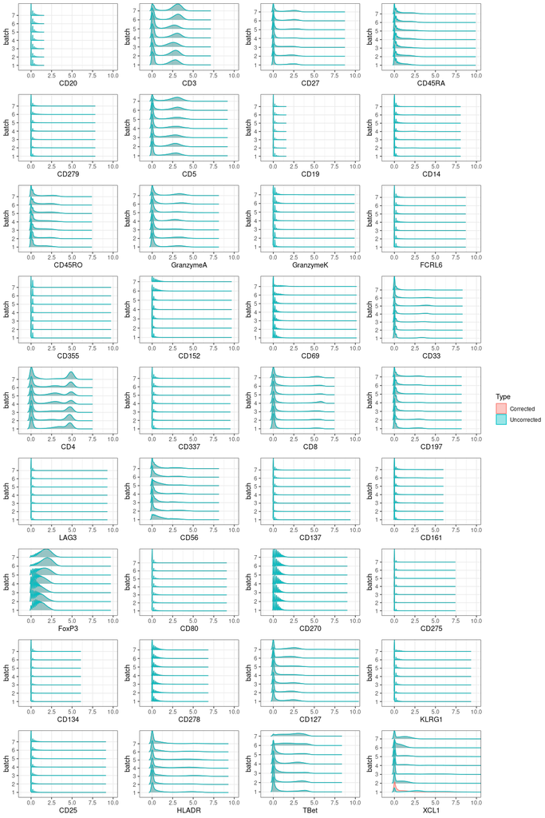

```r
plot_density(dfci, imputed, ncol = 4)
```

Notice how it is only the expression of XCL1 in the single batch, batch 1, which has changed compared to the raw data. This is exactly what we wanted. Furthermore, look how nicely the distribution of the marker corresponds to those in the other six batches.